# Kushagra Agarwal

```python
import numpy as np
import matplotlib.pyplot as plt
%matplotlib inline
```

**Molecular Dynamics**, these equations are used for each particle in every update step: $ \vec{F_{ext,i}} = \frac{d\vec{p_i}}{dt} = - \vec{\nabla}U $ and $ \vec{p_i} = m_i \frac{d\vec{r_i}}{dt} $

# Lesson-4: Molecular Dynamics

- Molecular Dynamics is essentially the application of the Newtons Second Law to molecules, where the force acting on each part of the molecule is computed by modelling its interaction with every other part of the system.
- Total potential energy of the system: $$ U = \sum_{i\in\{bonds\}} \frac{1}{2} k_i (d_i - d_{0,i})^2 + \sum_{i\in\{angles\}} \frac{1}{2} k_i (\theta_i - \theta_{0,i})^2 + \sum_{i\in\{dihedrals\}} \phi ( cos(n\theta_i)-1) + \sum_{i,j\in\{non-bond~pairs\}} ( U_{LJ}(i,j) + U_{Columbic}(i,j)) $$
- Equations of motion given by: $$ \frac{d\vec{p}_i}{dt} = \vec{F}_i \\ \frac{d \vec{r}_i}{dt} = \vec{p}_i/m_i $$
- Euler Method: $$ \vec{p}_i(t+dt) = \vec{p}_i(t) + dt~\vec{F}_i(t) \\ \vec{r}_i(t+dt)=\vec{r}_i(t) + dt\vec{p}_i/m_i $$
- Check on accuracy: constant total energy, total linear momentum
- Example: Simple harmonic oscillator

## Example: Argon

Argon atom is electrically neutral and a good model for the pair-wise interaction between two Argon atoms is given by Lennard-Jones potential, whose functional form is given by: $$ U_{LJ} (\vec{r}_i,\vec{r}_j) = 4 \epsilon \left( \left(\frac{\sigma}{r} \right)^{12}- \left(\frac{\sigma}{r} \right)^6 \right) $$ where $\vec{r} = \vec{r}_i - \vec{r}_j$ and $r=|\vec{r}|$. The force on particle $i$ due to its interaction via LJ potenital with particle $j$ is then given by: $$-\left( \frac{\partial U_{LJ}}{\partial x_i}, \frac{\partial U_{LJ}}{\partial y_i},\frac{\partial U_{LJ}}{\partial z_i} \right)$$ And the total potential of the system of $N$ Argon atoms is sum of all the pairwise interactions, i.e., $$ U = \frac{1}{2} \sum_{i,j=1, i\ne j}^N U_{LJ} (\vec{r}_i,\vec{r}_j) $$ Using the Euler method mentioned above, write a program to compute the trajectory of the system! Following functions might need to be written:

- `euler_integrate(timestep)`
- `initialise_config`
- `initialise_momenta`
- `compute_force`, `compute_pairwiseLJ(i,j,sigma,epsilon)`

```python
# Each of the Potential Functions
fLJ = lambda r, atom: 4 * atom.epsilon * (12*(atom.sigma)**12/(r**13) - 6*(atom.sigma**6)/(r**7))
fES = lambda r: 1 / (r**2)
fKX = lambda r: - 1 * r
vLJ = lambda r, atom: 4*atom.epsilon * ((atom.sigma/r)**12 - (atom.sigma/r)**6) if r != 0 else 0
vES = lambda r: - 1 / r
vKX = lambda r: 0.5 * (r ** 2)
```

```python
class Atom:

    def __init__(self, r = np.zeros(3), p = np.zeros(3), m = 1.0,
                 sigma = 1.0, epsilon = 1.0, label='ATOM (unlabelled)'):
        self.r, self.p, self.m = r, p, m
        self.sigma, self.epsilon, self.label = sigma, epsilon, label
        assert type(self.r) is np.ndarray and len(self.r.shape) is 1 and self.r.shape[0] is 3
        assert type(self.p) is np.ndarray and len(self.p.shape) is 1 and self.p.shape[0] is 3
        assert type(self.sigma) is float and type(self.epsilon) is float and type(self.m) is float

    def __str__(self):
        return "Atom: " + str(self.label) + "\nPosition: " + str(self.r) + "\nMomentum: " + str(self.p)

    def force(self, atoms, v = lambda r, atom: fKX(r)):
        force = np.zeros(3)
        for atom in atoms:
            rad = self.r - atom.r
            force += (v(np.linalg.norm(rad), atom) * rad / np.linalg.norm(rad)) \
                        if np.linalg.norm(rad) != 0 else np.zeros(3)
        assert type(force) is np.ndarray and len(force.shape) is 1 and force.shape[0] is 3
        return force

    def update(self, atoms, dt = 0.001, v = lambda r, atom: fKX(r)):
        self.p += self.force(atoms, v) * dt
        self.r += self.p * dt / self.m
        assert type(self.r) is np.ndarray and len(self.r.shape) is 1 and self.r.shape[0] is 3
        return self.r

    def kineticEnergy(self):
        return 0.5 * np.linalg.norm(self.p)**2 / self.m

    def potentialEnergy(self, atoms, v = lambda r, atom: vKX(r)):
        total = 0
        for atom in atoms:
            total += v(np.linalg.norm(self.r - atom.r), atom)
        return total
```

Small check to evaluate **Lennard-Jones potential** at every distance along the X-axis.

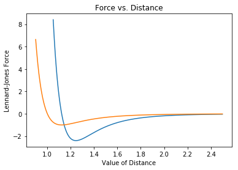

```python
x = Atom(np.array([0, 0, 0]))
scanFR = np.arange(1.05, 2.5, 0.001)
force = [x.force([Atom(r = np.array([pos, 0, 0]))], v = lambda r, atom: -fLJ(r, atom))[0] for pos in scanFR]
scanPE = np.arange(0.9, 2.5, 0.001)
potential = [x.potentialEnergy([Atom(r = np.array([pos, 0, 0]))], v = lambda r, atom: vLJ(r, atom)) for pos in scanPE]

plt.plot(scanFR, force, label='Force')
plt.plot(scanPE, potential, label='Potential')
plt.xlabel('Value of Distance')
plt.ylabel('Lennard-Jones Force')
plt.title('Force vs. Distance')
plt.show()
```

Checking with **Simple Harmonic Potential** if the Update functions work in all 3-dimensions.

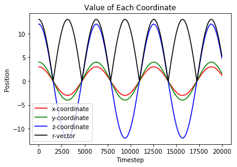

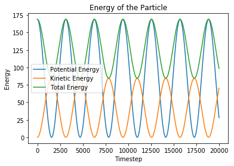

```python
a = Atom(np.array([0., 0., 0.]))
b = Atom(np.array([3., 4., 12.]))

x, y, z, pe, ke = np.array([]), np.array([]), np.array([]), np.array([]), np.array([])
for _ in range(20000):
    pos = b.update([a])
    x = np.append(x, pos[0])
    y = np.append(y, pos[1])
    z = np.append(z, pos[2])
    pe = np.append(pe, b.potentialEnergy([a]))
    ke = np.append(ke, b.kineticEnergy())

plt.plot(x, 'r', label='x-coordinate')
plt.plot(y, 'g', label='y-coordinate')
plt.plot(z, 'b', label='z-coordinate')
plt.plot((x**2 + y**2 + z**2)**0.5, 'k', label='r-vector')
plt.title('Value of Each Coordinate')
plt.legend()
plt.xlabel('Timestep')
plt.ylabel('Position')
plt.show()
plt.plot(pe * 2, label='Potential Energy') # Since it did not doubly count the Potential Energy
plt.plot(ke, label='Kinetic Energy')
plt.plot(ke + (pe * 2), label='Total Energy')
plt.legend()
plt.title('Energy of the Particle')
plt.xlabel('Timestep')
plt.ylabel('Energy')
plt.show()
```

```python
def writeTrajectory(atoms = [], time = 0.0):
    with open('_coordinate.dat', 'w') as f:
        f.write('\n:: ++++++++++++++++++++ TIMESTEP = ' + str(time) + ' ++++++++++++++++++++\n')
        for atom in atoms:
            f.write(str(atom) + '\n')
```

## Running the Simulation

The atoms are initialized with random positions, nil momenta, and 1.0 values for $\epsilon$ and $\sigma$. The **Kinetic and Potential Energies** are maintained. The final plot is the scatter of the **final locations** of the particles.

```python
# Initialize all atoms
atoms = [Atom(r=np.random.random(3)*20, p=np.zeros(3), m=1.0, sigma=1.0, epsilon=1.0) for _ in range(100)]
kinetic, potential = np.array([]), np.array([])

x, y, z = [], [], []
# Update all atoms for many timesteps
for time in range(200):
    ke, pe = 0.0, 0.0
    for atom in atoms:
        atom.update(atoms, v = lambda r, atom: fLJ(r, atom), dt = 0.001)
        ke, pe = ke + atom.kineticEnergy(), pe + atom.potentialEnergy(atoms, v = lambda r, atom: vLJ(r, atom))
    kinetic, potential = np.append(kinetic, ke), np.append(potential, pe/2)
    if (time % 10 == 0):
        writeTrajectory()
    # Get the positions of each atom
    x.append([atom.r[0] for atom in atoms])
    y.append([atom.r[1] for atom in atoms])
    z.append([atom.r[2] for atom in atoms])
```

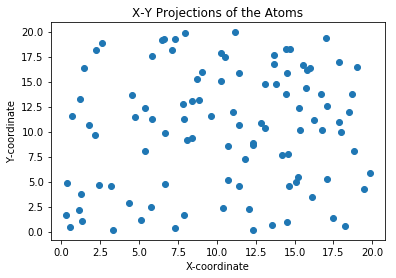

```python
plt.scatter(x[-1], y[-1])
plt.title('X-Y Projections of the Atoms')
plt.xlabel('X-coordinate')
plt.ylabel('Y-coordinate')
plt.show()
```

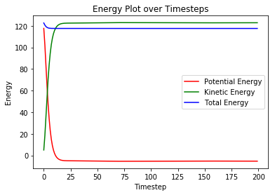

```python
plt.plot(potential, 'r', label='Potential Energy')
plt.plot(kinetic, 'g', label='Kinetic Energy')
plt.plot((kinetic + potential), 'b', label='Total Energy')
plt.legend()
plt.title('Energy Plot over Timesteps')
plt.ylabel('Energy')
plt.xlabel('Timestep')
plt.show()
```

A zoom in on the plot as the potential energy, kinetic energy and total energy. The Total energy remains constant, though changes a little due to simulation issues.

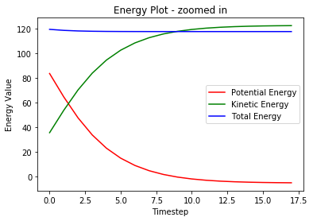

```python
plt.plot(potential[2:20], 'r', label='Potential Energy')
plt.plot(kinetic[2:20], 'g', label='Kinetic Energy')
plt.plot((kinetic[2:20] + potential[2:20]), 'b', label='Total Energy')
plt.legend()
plt.ylabel('Energy Value')
plt.xlabel('Timestep')
plt.title('Energy Plot - zoomed in')
plt.show()
```